# Introduction to DICE

Qi Luo and Andrew E Teschendorff

2022-05-26

#### Package

DICE 0.9.1

# Contents

> **Abstract: DICE is an R-package which uses the concept of Distance Covariance Entropy to help quantify bifurcation dynamics from scRNA-Seq data. Specifically, the package provides a suite of functions to quantify the degree of priming of a multipotent cell population in the context of a scRNA-Seq dataset encompassing multipotent cells as well as more mature cell populations representing competing downstream lineages. The package uses Distance Covariance Entropy (DICE) not only to quantify the degree of priming, but also to identify candidate regulatory factors implicated in priming as well as the corresponding primed cells. This methodology, which only requires scRNA-Seq data, has however been validated in datasets with matched scATAC-Seq data, either in the same cells (SHARE-Seq) or in separate cell populations representing the same cell-types.**

# 1 Motivation and Background

Single-cell RNA-Seq (scRNA-Seq) data offers the opportunity to study the dynamics of cell-fate transitions at an unprecedented detail. Key challenges that can be addressed with single-cell data are the identification of regulatory factors controling such transitions, including those that are implicated in the earliest stages of the cell-fate commitment process. This stage of early commitment among multi-or-bipotent cells is commonly known as priming. In addition, the timing of bifurcations of multipotent states into downstream competing lineages is complicated due to the inherent sparseness of scRNA-Seq data around such bifurcation points. The DICE R-package provides a suite of functions to help address some of these challenges. The acronym DICE stands for DIstance Covariance Entropy, which is a novel metric we introduce in Q. Luo and Teschendorff (2022) , to quantify the overall degree of dependence between a set of regulatory factors (RFs) across a pool of cells. In practice this pool of cells refers to a multi-or-bi potent cell population representing a cellular state that bifurcates into a number of competing downstream lineages. DICE is in effect a covariance entropy (Wieringen and Vaart (2010)) but computed over the distance covariance matrix (Ghanbari, Lasserre, and Vingron (2019) , Székely and Rizzo (2017)), as opposed to the ordinary covariance matrix. The distance covariance matrix allows not only non-linear associations between RFs to be identified, but also non-monotonic ones which could be missed with non-parametric correlations metrics such as Spearman.

In this tutorial vignette, we describe three potential applications of **DICE**:

1. Quantification of priming in a multipotent cell population.
2. Identification of RFs controling priming into a given lineage.
3. Estimating the timing of bifurcations from timecourse scRNA-Seq data.

To illustrate these applications, we will use two scRNA-Seq datasets:

1. A scRNA-Seq dataset from A. M. Ranzoni and Cvejic (2021) , representing the bifurcation of hematopoietic multipotent progenitor cells (MPPs) into granulocyte progenitors (GPs) and megakaryocyte-erythroid-mast progenitors (MEMPs) during fetal liver hematopoiesis. This dataset is chosen because there is matched scATAC-Seq data for the same cell-types, allowing validation of the DICE predictions. However, the current version of DICE only operates on scRNA-Seq data, with the scATAC-Seq only meant to validate results obtained on scRNA-Seq data. As such, one of the goals of DICE is to demonstrate how it is possible to identify primed cellular states from scRNA-Seq data only, without the need for scATAC-Seq.
2. A timecourse scRNA-Seq dataset of liver differentiation where mouse hepatoblasts are differentiated into hepatocytes and cholangiocytes (Yang et al. (2017)) .

# 2 Tutorial Example: priming during fetal liver hematopoiesis

In order to run the tutorial we must first load in the necessary library and data objects:

## 2.1 Loading in the scRNA-Seq data

```r
library(DICE);
data(ranzoni);
data(humanTF);
ls();
```

```
##  [1] "atac.GP.prime.cell.v"   "atac.MEMP.prime.cell.v" "b"
##  [4] "bin.o"                  "brch1.idx"              "brch2.idx"
##  [7] "crf.o"                  "dat"                    "dc.m"
## [10] "dice.v"                 "diceBoot.m"             "dmap.o"
## [13] "dpt.o"                  "dpt.v"                  "e10.idx"
## [16] "end.idx"                "fit"                    "GP.access.m"
## [19] "GP.sum.atac.v"          "humanTF.v"              "lin"
## [22] "MEMP.access.m"          "MEMP.sum.atac.v"        "mpp.idx"
## [25] "nBoots"                 "ncpct.v"                "overlap.v"
## [28] "p1"                     "p2"                     "p3"
## [31] "p4"                     "pest.v"                 "prf.lv"
## [34] "prfac.lo"               "primedCellMarker.l"     "primedCells.li"
## [37] "prpval.lo"              "r"                      "ranzoni.branch.pr.m"
## [40] "ranzoni.gene.access.m"  "ranzoni.m"              "ranzoni.TFA.m"
## [43] "ranzoniCT.v"            "root.idx"               "sd.v"
## [46] "selTF.v"                "sigUP.idx"              "stat.m"
## [49] "statEND.m"              "symsigF"                "tt.o"
## [52] "use_GP_marker.v"        "use_MEMP_marker.v"      "x"
## [55] "y"                      "yangLiver"              "yangTFA.m"
## [58] "yangTP.v"               "yfit"
```

```r
ncpct.v <- summary(factor(ranzoniCT.v));
print(ncpct.v);
```

```
##        Comm-Prog Granulocyte Prog              MPP
##              192              177             1200
```

We are interested in assessing whether there is priming in the MPP cell population in relation to differentiation into either the granulocyte or megakaryote-erythrocyte lineage. The data itself is defined for 177 cells representing granulocyte progenitors (GPs), 192 common progenitors representing megakaryocte-erythrocyte-mast progenitors (MEMPs) and 1200 MPPs.

The other object loaded in is `humanTF.v`. This is a vector encoding human regulatory factors. Because the `ranzoni.m` data matrix has already been reduced to only contain regulatory factors, in this particular case we don't need `humanTF.v`, but more generally if our data matrix were to be defined for all genes, we would want to use `humanTF.v` to select out the expression profiles for these RFs.

## 2.2 Identifying candidate regulatory factors for priming

The first step in our analysis is to identify candidate RFs that may be implicated in priming by performing a differential overexpression analysis, comparing progenitors of one lineage to MPPs as well as to progenitors of the other lineage. We can accomplish this using the `FindCandidateFactors` function:

```r
crf.o <- FindCandidateFactors(ranzoni.m,rf.v=humanTF.v,celltypes.v=ranzoniCT.v,mpp="MPP",linCT.v=c("Granulocyte Prog","Comm-Prog"),sigth=NULL,type1fth="Mean");
```

```
## [1] "Found 18 candidate RFs for lineage Granulocyte Prog"
## [1] "Filtering candidate RFs by frequency of expression in MPPs"
## [1] "Left with 10 candidate RFs for lineage Granulocyte Prog"
## [1] "Found 20 candidate RFs for lineage Comm-Prog"
## [1] "Filtering candidate RFs by frequency of expression in MPPs"
## [1] "Left with 7 candidate RFs for lineage Comm-Prog"
```

```r
names(crf.o) <- c("GP","MEMP");
```

Of note, this function also does a filtering of candidate RFs by their frequency of expression in the MPP cell population. In particular, it only keeps RFs with a frequency of expression in the MPP population less than the mean value as computed over all candidate overexpressed RFs, as indicated by the `type1fth` argument. The rationale for this filtering is that the fraction of MPP cells primed to a given lineage is expected to be a low number. If no filtering by frequency is desired, the user can set `type1fth` to `NULL`.

## 2.3 Quantification of priming in multipotent cell population

Having identified the candidate regulatory factors for each lineage, we now proceed to assess whether there is any evidence of priming into these lineages. This can be accomplished with the `CompDICE` and `CompPrimingPval` functions. We run the `CompDICE` function to estimate the distance covariance entropy of the candidate RFs for each lineage:

```r
mpp.idx <- which(ranzoniCT.v=="MPP");
dice.v <- vector();
for(lin in 1:2){
 dice.v[lin] <- CompDICE(ranzoni.m[names(crf.o[[lin]]),mpp.idx], useSpear=FALSE, std=TRUE)$dice;
}
names(dice.v) <- names(crf.o);
print(dice.v);
```

```
##           GP         MEMP
## -0.002170075 -0.005169254
```

We now compare these estimated DICE values to those of randomized data matrices, using the `CompPrimingPval` function, which effectively computes a P-value of significance that the observed DICE values are lower than those of a null distribution given by randomization of the data matrices:

```r
prpval.lo <- list();
for(lin in 1:2){
 prpval.lo[[lin]] <- CompPrimingPval(ranzoni.m[names(crf.o[[lin]]),mpp.idx], dice=dice.v[lin], nMC=100, ncores=4);
}
names(prpval.lo) <- names(crf.o);
print(prpval.lo[[1]]$pval);
```

```
## [1] 0
```

```r
print(prpval.lo[[2]]$pval);
```

```
## [1] 0
```

These are empirical P-values and since the number of Monte-Carlo runs was set to 100, this means that the P-values are less than 0.01. In practice, we obviously advise at least 1000 Montte-Carlo runs to ensure P-values are stable. Given that the observed DICE values are lower than those of the null distribution, this would suggest that priming towards the GP and MEMP lineages is indeed present in the MPP cell population. We can generate a figure to confirm the statistical significance of the P-values:

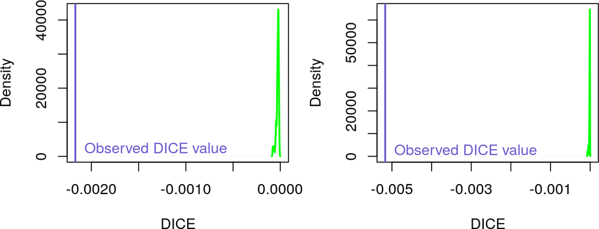

```r
par(mfrow=c(1,2));
par(mar=c(4,4,2,1));
for(lin in 1:2){
 plot(density(prpval.lo[[lin]]$null),col="green",lwd=2,xlim=c(dice.v[lin],0),xlab="DICE",ylab="Density",main="");
 abline(v=dice.v[lin],col="slateblue",lwd=2);
 text(x=dice.v[lin],y=2000,"Observed DICE value",col="slateblue",pos=4);
}
```

## 2.4 Characterization of the primed states

The next step is to characterize the primed states, i.e the identification of regulatory factors driving the priming as well as the corresponding primed cells. We can accomplish these tasks using the `FindPrimingFactors` and `FindPrimedCells` functions.

```r
prfac.lo <- list();
for(lin in 1:2){
 prfac.lo[[lin]] <- FindPrimingFactors(ranzoni.m[names(crf.o[[lin]]),mpp.idx]);
}
```

```
## [1] "Doing perturbation LOO DICE analysis"
## [1] "Doing Spearman analysis"
## [1] "Doing perturbation LOO DICE analysis"
## [1] "Doing Spearman analysis"
```

```r
names(prfac.lo) <- names(crf.o);
```

Let us now study the output from this function. Let us first consider the GP-lineage.

```r
print(prfac.lo$GP$rankedLOO);
```

```
##  [1] "IRF8"  "UHRF1" "HLX"   "RUNX2" "CEBPA" "MEF2D" "SPI1"  "GFI1"  "FOSL2"
## [10] "CEBPD"
```

```r
head(prfac.lo$GP$rankedPairs);
```

```
##                   SCC            P
## IRF8:UHRF1  0.2449716 7.387985e-18
## RUNX2:UHRF1 0.1526805 1.068429e-07
## CEBPA:IRF8  0.1359032 2.302787e-06
## HLX:IRF8    0.1354079 2.508051e-06
## IRF8:RUNX2  0.1228640 1.973403e-05
## IRF8:MEF2D  0.1102430 1.299157e-04
```

The first output `rankedLOO` ranks the candidate RFs by a leave-one-out (LOO) analysis, whereby each RF was removed whilst recomputing DICE. Thus, the top RFs in this list are the ones for which their removal leads to largest increases in DICE, corresponding to the largest increases in randomness. Thus, these RFs are important drivers of priming (lowering of entropy). As we can see, UHRF1 and IRF8 are the top 2 RFs. The second output `rankedPairs` ranks pairs of RFs according to a Spearman rank correlation, which complements the DICE analysis. Using this dual perturbation/LOO - Spearman correlation analysis, we can thus observe that UHRF1-IRF8 is the top-ranking pair, and therefore this pair would be a candidate pair for priming factors into the GP lineage.

As far as the MEMP-lineage is concerned:

```r
print(prfac.lo$MEMP$rankedLOO);
```

```
## [1] "GATA1" "KLF1"  "FHL2"  "GFI1B" "IKZF2" "TAL1"  "HLTF"
```

```r
head(prfac.lo$MEMP$rankedPairs);
```

```
##                    SCC            P
## GATA1:KLF1  0.24305333 1.351470e-17
## FHL2:GATA1  0.13679413 1.973458e-06
## FHL2:GFI1B  0.12573241 1.252145e-05
## FHL2:TAL1   0.09992019 5.274628e-04
## GFI1B:TAL1  0.09704328 7.623302e-04
## GFI1B:IKZF2 0.08451269 3.391835e-03
```

Again, there is a clear pair of regulatory factors (GATA1-KLF1) that stands out as priming factors for the MEMP lineage. Note that we are not stating that these are the only important factors, but rather that the output of the above function provides a list of the most likely priming factors.

To find the cells primed for the GP and MEMP lineages, we can now run:

```r
prf.lv <- list(GP=c("UHRF1","IRF8"),MEMP=c("GATA1","KLF1"));
primedCells.li <- FindPrimedCells(ranzoni.m[,mpp.idx],prf.lv);
print(paste("Fraction of MPP GP-primed cells=",round(length(primedCells.li$GP)/length(mpp.idx),3),sep=""));
```

```
## [1] "Fraction of MPP GP-primed cells=0.073"
```

```r
print(paste("Fraction of MPP MEMP-primed cells=",round(length(primedCells.li$MEMP)/length(mpp.idx),3),sep=""));
```

```
## [1] "Fraction of MPP MEMP-primed cells=0.02"
```

Thus, we can see that the fraction of GP and MEMP primed cells is only around 7 and 2%, respectively. In absolute numbers these are 88 GP-primed and 24 MEMP-primed cells.

## 2.5 Validation of primed states

We now aim to validate these primed states. We do this following two independent strategies. In one approach, we run Palantir (Setty et al. (2019)) to estimate cell-fate probabilities for all MPP cells. Those cells we have predicted to be primed for GP and MEMP lineages should exhibit higher cell-fate probabilities for the corresponding lineage. Because Palantir is a Python module, we simply load in the cell-fate probability output from Palantir:

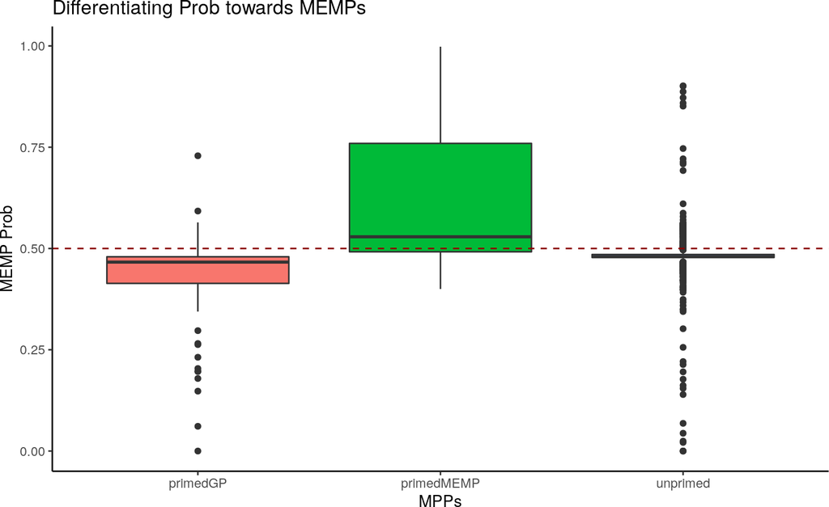

```r
library(ggplot2);
library(ggpubr);
data(ranzoniBranchPr)
dat <- data.frame(MEMP_pr=ranzoni.branch.pr.m$MEMP_pr,Celltype=ranzoniCT.v)
dat[mpp.idx[primedCells.li$GP],'Celltype'] <- 'primedGP'
dat[mpp.idx[primedCells.li$MEMP],'Celltype'] <- 'primedMEMP'
dat[dat$Celltype=='MPP','Celltype'] <- 'unprimed'
ggplot()+geom_boxplot(data=dat[ranzoniCT.v=='MPP',],aes(x=Celltype,y=MEMP_pr,fill=Celltype))+
  labs(title='Differentiating Prob towards MEMPs',
       x='MPPs',y='MEMP Prob')+
  geom_hline(yintercept = 0.5,col='darkred',linetype='dashed')+
  geom_signif(comparisons = list(c('primedMEMP','primedGP'),
                                 c('primedMEMP','unprimed')),
              test='wilcox.test',test.args = list(alternative='gr'),
              y_position = c(0.8,0.9),textsize = 4,
              map_signif_level = function(x){return(paste0('P=',signif(x,2)))})+
  theme_classic()+
  guides(fill='none')
```

We can see that the estimated probabilities of differentation into the MEMP lineage are indeed significantly higher for the cells we have predicted to be MEMP-primed, thus validating our assignments.

However, this validation is run on the same scRNA-Seq data, and thus ideally one would seek a validation using independent data or an independent data-type. To this end, we use matched scATAC-Seq data from the same Ranzoni et al study (A. M. Ranzoni and Cvejic (2021)). To clarify, these scATAC-Seq profiles are not available for exactly the same cells, but they are available for the same cell-types.

Because the scATAC-Seq data is not available for exactly the same cells, we must first identify the corresponding primed cells in the scATAC-Seq data. To this end, we use Wilcoxon rank sum tests to obtain marker genes (not restricted to RFs) with significantly higher expression in primedMEMPs or primedGPs, compared to all other MPPs. Since this computation would require a fairly large data matrix, further below we once again load in the precomputed lists of marker genes. With these marker genes, we can then use the scATAC-Seq peak-level data to generate a gene-level accessibility count matrix by aggregating peaks within a region 3kb upstream of each marker gene and gene body, and then log-normalize the gene accessible count matrix with Seurat. MPP cells primed to MEMP-lineage were then defined as the top-10% cells with the highest average gene-marker accessibility as estimated over all marker genes for primedMEMPs. An analogous procedure was used to defined GP-primed cells. Again, for the purpose of generating this vignette in a reasonable timeframe we load in the marker-gene lists and normalized gene-level accessibility matrix for the MPP cells:

```r
library(Matrix)
data(ranzoniATAC)

# primedMEMPs for scATAC-Seq data
use_MEMP_marker.v <- intersect(rownames(ranzoni.gene.access.m), primedCellMarker.l$primedMEMP)
print(length(use_MEMP_marker.v))
```

```
## [1] 465
```

```r
MEMP.access.m <- ranzoni.gene.access.m[use_MEMP_marker.v,]
MEMP.sum.atac.v <- colSums(MEMP.access.m)
atac.MEMP.prime.cell.v <- names(MEMP.sum.atac.v)[MEMP.sum.atac.v>quantile(MEMP.sum.atac.v,0.9)]
print(length(atac.MEMP.prime.cell.v))
```

```
## [1] 227
```

```r
# primedGPs for scATAC-Seq data
use_GP_marker.v <- intersect(rownames(ranzoni.gene.access.m), primedCellMarker.l$primedGP)
print(length(use_GP_marker.v))
```

```
## [1] 482
```

```r
GP.access.m <- ranzoni.gene.access.m[use_GP_marker.v,]
GP.sum.atac.v <- colSums(GP.access.m)
atac.GP.prime.cell.v <- names(GP.sum.atac.v)[GP.sum.atac.v>quantile(GP.sum.atac.v,0.9)]
print(length(atac.GP.prime.cell.v))
```

```
## [1] 227
```

```r
# exclude the overlapped primed cells
overlap.v <- intersect(atac.MEMP.prime.cell.v,atac.GP.prime.cell.v)
atac.MEMP.prime.cell.v <- setdiff(atac.MEMP.prime.cell.v,overlap.v)
atac.GP.prime.cell.v <- setdiff(atac.GP.prime.cell.v,overlap.v)
print(paste0('# of primedMEMPs=',length(atac.MEMP.prime.cell.v)))
```

```
## [1] "# of primedMEMPs=160"
```

```r
print(paste0('# of primedGPs=',length(atac.GP.prime.cell.v)))
```

```
## [1] "# of primedGPs=160"
```

Having identified the primed cells in the scATAC-Seq data, we now validate them using `chromVAR` (Shep et al. (2017)). `chromVAR` takes as input a TF and associated binding motif, and the peak-level scATAC-Sqe data, to compute an activity score that reflects the overall accessibility of the TF's binding motifs. Due to the size of the peak-level data, we here load in the precomputed TF activity (TFA) data for MPPs, `ranzoni.TFA.m`. This was loaded in earlier with `data(ranzoniATAC)`. Note that since our previous prediction involved KLF1 and GATA1 as priming factors for MEMP lineage, that we focus on these two TFs:

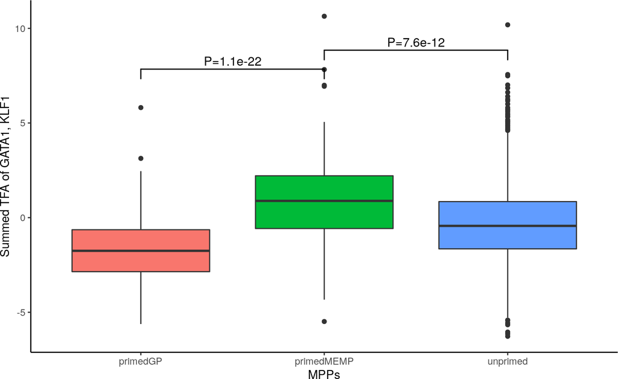

```r
dat <- data.frame(TFA=(ranzoni.TFA.m['GATA1',]+ranzoni.TFA.m['KLF1',]),Celltype='unprimed')

dat[atac.MEMP.prime.cell.v,]$Celltype <- 'primedMEMP'
dat[atac.GP.prime.cell.v,]$Celltype <- 'primedGP'

ggplot(aes(x=Celltype,y=TFA,fill=Celltype),data=dat)+
  geom_boxplot()+
  labs(x='MPPs',y='Summed TFA of GATA1, KLF1')+
  geom_signif(comparisons = list(c('primedMEMP','primedGP'),
                                 c('primedMEMP','unprimed')),
              test='wilcox.test',test.args = list(alternative='gr'),
              y_position = c(7,8),textsize = 4,
              map_signif_level = function(x){return(paste0('P=',signif(x,2)))})+
  theme_classic()+
  guides(fill='none')
```

We can see that the average TFA values over GATA1 and KLF1 are indeed significantly higher in the cells we have predicted to MEMP-primed. Now we do the corresponding analysis for the GP-lineage. Note that for the GP-lineage our priming pair was UHRF1-IRF8, but that for UHRF1 (not being a TF) we can't compute TFA using `chromVAR`. Thus, for the GP-lineage we can only do the validation for IRF8:

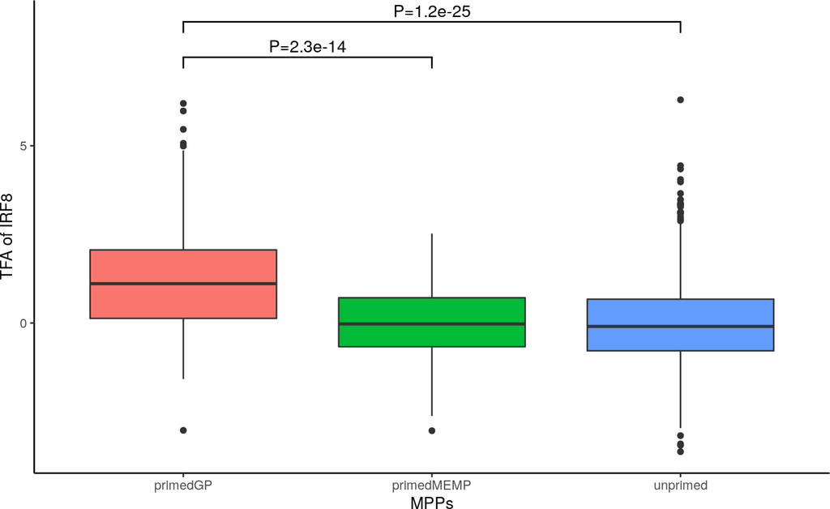

```r
dat <- data.frame(TFA=(ranzoni.TFA.m['IRF8',]),
                Celltype='unprimed')
dat[atac.MEMP.prime.cell.v,]$Celltype <- 'primedMEMP'
dat[atac.GP.prime.cell.v,]$Celltype <- 'primedGP'

ggplot(aes(x=Celltype,y=TFA,fill=Celltype),data=dat)+
  geom_boxplot()+
  labs(x='MPPs',y='TFA of IRF8')+
  geom_signif(comparisons = list(c('primedGP','primedMEMP'),
                                 c('primedGP','unprimed')),
              test='wilcox.test',test.args = list(alternative='gr'),
              y_position = c(7,8),textsize = 4,
              map_signif_level = function(x){return(paste0('P=',signif(x,2)))})+
  theme_classic()+
  guides(fill='none')
```

# 3 Application of DICE to timing of bifurcations

To illustrate how DICE can be used to help pinpoint the timing of bifurcation points, we consider a timecourse differentiation scRNA-Seq dataset of mouse hepatoblasts into cholangiocytes and hepatocytes (Yang et al. (2017)). There are a total of 447 cells distributed across 7 timepoints (E10, E11, E12, E13, E14, E15 and E17).

## 3.1 Loading in the scRNA-Seq data and generating the diffusion map

We first load in the data as well as a number of packages needed to run this analysis:

```r
library(Biobase);
library(destiny);
library(Hmisc);
library(gridExtra);
data(yangLiver);
yangLiver;
```

```
## ExpressionSet (storageMode: lockedEnvironment)
## assayData: 22 features, 447 samples
##   element names: exprs
## protocolData: none
## phenoData
##   sampleNames: E10.5D_1_01 E10.5D_1_02 ... E17.5E_4_16 (447 total)
##   varLabels: TimeIDX Time
##   varMetadata: labelDescription
## featureData: none
## experimentData: use 'experimentData(object)'
## Annotation:
```

```r
phenoData(yangLiver);
```

```
## An object of class 'AnnotatedDataFrame'
##   sampleNames: E10.5D_1_01 E10.5D_1_02 ... E17.5E_4_16 (447 total)
##   varLabels: TimeIDX Time
##   varMetadata: labelDescription
```

```r
summary(factor(phenoData(yangLiver)$Time));
```

```
## E10 E11 E12 E13 E14 E15 E17
##  54  70  41  65  70  77  70
```

Whilst it is possible to analyse the scRNA-Seq data from Yang et al. (2017) by starting out from the full gene expression data matrix, what we have done to reduce package-size and to speed up the computational analysis is to load in a data matrix defined over 22 liver-specific transcription factors (TFs), whose role in liver differentiation has been previously validated (A. Teschendorff and Wang (2020)). Moreover, instead of using TF-expression, we use estimated transcription factor differentiation activity (TFA) values. These TFA-values are a measure of differentiation activity, derived from corresponding TF-regulons, and have been shown to display better sensitivity than TF-expression values (A. Teschendorff and Wang (2020)).

Next, we confirm that the majority of these 22 liver-specific TFs display increased differentiation activity with developmental timepoint:

```r
yangTFA.m <- exprs(yangLiver);
yangTP.v <- phenoData(yangLiver)$TimeIDX;
stat.m <- matrix(apply(yangTFA.m,1,function(v) { summary(lm(v ~ yangTP.v))$coeff[2,3:4];}),ncol=2,byrow=TRUE);
print(summary(factor(sign(stat.m[which(stat.m[,2] < 0.05/nrow(yangTFA.m)),1]))));
```

```
## -1  1
##  2 16
```

We can see that 16 of the 22 TFs display significantly increased differentiation activity with developmental timepoint, thus validating the majority of them. Nevertheless, we proceed with all 22 TFs to derive a diffusion map over these 22 factors and to infer lineage trajectories. For this we use the DiffusionMap function from the `destiny` R-package:

```r
dmap.o <- DiffusionMap(data=yangLiver,k=30,verbose=TRUE);
```

```
## finding knns......done. Time: 0.06s
## Calculating transition probabilities......done. Time: 0.09s
##
## performing eigen decomposition......done. Time: 0.04s
```

```r
dc.m <- eigenvectors(dmap.o);
head(cor(dc.m,yangTP.v));
```

```
##            [,1]
## DC1  0.85961537
## DC2  0.11266668
## DC3 -0.09532010
## DC4 -0.09086174
## DC5  0.01569915
## DC6 -0.04409283
```

We can see from the above, that diffusion component-1 (DC1) associates very strongly with developmental timepoint. To infer pseudotime, we also need to specify the root-state. This can be done in many different ways, and users are free to use their favourite method to propose a root-state. Given the strong association of DC1 with developmental timepoint, we pick as root-state the cell from E10 with the largest absolute DC1 value.

```r
e10.idx <- which(yangTP.v==1);
root.idx <- e10.idx[which.max(abs(dc.m[e10.idx,1]))];
dpt.o <- DPT(dmap.o,tips=root.idx);
```

We are now ready to plot the diffusion map:

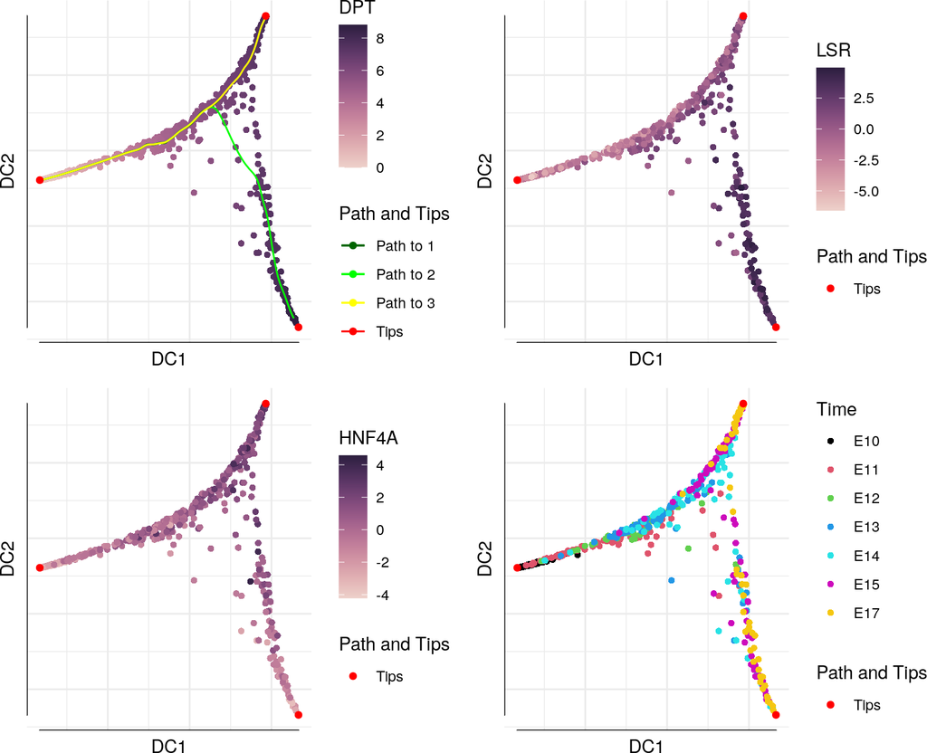

```r
par(mar=c(4,4,3,1));
p1 <- plot(dpt.o,dcs=1:2,col_by="dpt",paths_to=1:3,pch=23,col_path=c("darkgreen","green","yellow"),lwd=3);
p2 <- plot(dpt.o,dcs=1:2,col_by="HNF4A");
p3 <- plot(dpt.o,dcs=1:2,col_by="LSR");
p4 <- plot(dpt.o,dcs=1:2,col_by="Time");
grid.arrange(p1,p2,p3,p4,layout_matrix=matrix(1:4,nrow=2,ncol=2));
```

From left to right, the above figure displays the diffusion map with cells annotated by diffusion pseudotime (DPT), by the TFA of a hepatocyte-specific factor (HNF4A), by the TFA of a cholangiocyte-factor (LSR) and by developmental timepoint. From the diffusion map, we can observe the two branches of differentiation into hepatocytes and cholangiocytes. Whilst the lineage trajectory algorithm identifies a bifurcation point, the timing of this bifurcation in relation to the developmental timepoint is unclear. Hence, in what follows we use DICE to help pinpoint the timing of the bifurcation.

## 3.2 Identification of key transcription factors and DICE computation

Before computing DICE, we first identify the hepatocyte and cholangiocyte-specific TFs that display increased differentiation activity along the timecourse, and which do so specificly to each branch. To find these antagonistic TFs, we perform a differential TFA analysis between the cells of each terminal hepatocyte and cholangiocyte branch.

```r
sigUP.idx <- intersect(which(stat.m[,2]<0.05/nrow(stat.m)),which(stat.m[,1]>0));
end.idx <- which(yangTP.v==7); ## terminal cells
brch1.idx <- intersect(which(dc.m[,2] > 0.05),end.idx);
brch2.idx <- intersect(which(dc.m[,2] < -0.05),end.idx);
statEND.m <- yangTFA.m[,1:2];
colnames(statEND.m) <- c("t","P");
for(r in 1:nrow(statEND.m)){
    tt.o <- t.test(yangTFA.m[r,brch1.idx],yangTFA.m[r,brch2.idx]);
    statEND.m[r,] <- c(tt.o$stat,tt.o$p.value);
}
sort(statEND.m[sigUP.idx,1],decreasing=TRUE);
```

```
##      NR1I3      NR1I2      FOXA2     TRIM15      HNF4A    ONECUT1      HNF1A
##  23.959382  16.201844  12.461007  10.109419   9.940574   8.666378   5.216857
##       LHX2       BCL3       MYCL      FOXA1      HNF4G       IRF6        BGN
##   3.984556   3.077284   1.828549   1.159811  -1.584375  -5.763627  -6.159527
##       ELF3        LSR
## -12.266014 -12.966854
```

We can see from the sorted t-statistics of differential TFA, that there are 4 cholangiocyte-specific TFs (LSR, ELF3, IRF6 and BGN) and a larger number of hepatocyte factors. To compute DICE, we thus select the top-4 cholangiocyte (LSR, ELF3, IRF6 and BGN) and hepatocyte factors (NR1I3, NR1I2, FOXA2, TRIM15), respectively. Choosing an equal number of TFs for each branch is not essential but helps avoid biasing the inference to one particular lineage.

Next, we need to decide whether to compute DICE for each developmental timepoint, or for pseudotime bins. In this particular case, we use pseudotime bins, because the above diffusion map indicated substantial asynchrony between cells from different developmental timepoints, and because using bins ensures identical or near-identical cell numbers for each pseudotime bin.

```r
selTF.v <- c("LSR","ELF3","IRF6","BGN","NR1I3","NR1I2","FOXA2","TRIM15");
### find pseudotime
dpt.v <- dpt.o$DPT10; ## because root.idx is 10
bin.o <- CreateDPTbin(dpt.v,minBins=7);
dice.v <- vector();
for(b in 1:length(bin.o$binList)){
  dice.v[b] <- CompDICE(yangTFA.m[selTF.v,bin.o$binList[[b]]])$dice;
}
```

Now, we plot DICE as a function of pseudotime bin:

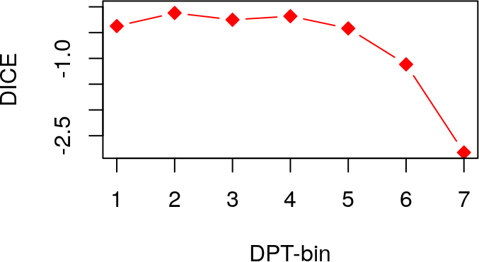

```r
plot(dice.v,xlab="DPT-bin",ylab="DICE",pch=23,col="red",bg="red",type="b",ylim=c(min(dice.v),0));
```

Thus, from the way DICE changes with DPT-bin, we can conclude that the bifurcation occurs between DPT-bin 5 and 6. In order to better assess this, we can determine sampling variability with a bootstrapping approach, which however we comment out here to avoid lengthy computation. Instead, we load in the precomputed bootstrapped values:

```r
nBoots <- 1000;
#diceBoot.m <- matrix(nrow=nBoots,ncol=length(bin.o$binList));
#for(bsi in 1:nBoots){
# for(bin in 1:length(bin.o$binList)){
#  tp.idx <- sample(bin.o$binList[[bin]],length(bin.o$binList[[bin]]),replace=TRUE);
#  diceBoot.m[bsi,bin] <- CompDICE(yangTFA.m[selTF.v,tp.idx])$dice;
# }
# print(paste("DOne Bootstrap-",bsi,sep=""));
#}
data(diceBoot);
```

Now, let us replot the dynamics of DICE with bootstrap confidence intervals and a symmetric sigmoid function fit:

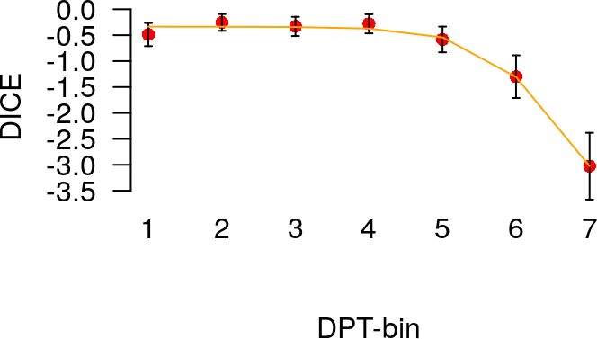

```r
sd.v <- apply(diceBoot.m,2,sd);
errbar(x=1:length(dice.v),y=colMeans(diceBoot.m), yplus=colMeans(diceBoot.m)+1.96*sd.v, yminus=colMeans(diceBoot.m)-1.96*sd.v, cap=0.015, main = NULL, add=FALSE, lty=1, type='p', ylim=NULL, lwd=1, pch=16, errbar.col="black",col="red",xlab="DPT-bin",ylab="DICE",cex=1,axes=FALSE);
axis(2,las=2,cex.axis=1);
mtext(side=1,line=0.1,at=1:length(dice.v),1:7,cex=1);

symsigF <- function(x,p1,p2,p3,p4){ p1 + p2/(1+exp(p3*(p4-x)))}
y <- colMeans(diceBoot.m)
x <- 1:7
fit <- nls(y ~ symsigF(x,p1,p2,p3,p4),data=data.frame(x,y),start=list(p1=-0.25,p2=-4,p3=2,p4=6));
pest.v <- coef(fit);
yfit <- symsigF(x,p1=pest.v[1],p2=pest.v[2],p3=pest.v[3],p4=pest.v[4]);
points(x,yfit,col="orange",type="l");
```

Thus, although the fit suggest that the bifurcation begins in DPT-bin 5, the bootstrapping analysis suggests that the bifurcation occurs immediately after DPT-bin 5. By studying the distribution of cells from bins 5 and 6 in relation to developmental timepoint we can now better pinpoint the bifurcation as occuring immediately after E14/E14.5:

```r
table(phenoData(yangLiver)$Time,bin.o$idx);
```

```
##
##        1  2  3  4  5  6  7
##   E10 49  5  0  0  0  0  0
##   E11 12 33 15  5  4  1  0
##   E12  1 13 17  7  2  1  0
##   E13  0 10 21 22  1  9  2
##   E14  1  1  9 18 24 10  7
##   E15  0  1  1 10 26 20 19
##   E17  0  0  0  1  6 22 41
```

# References

A. M. Ranzoni, I. Berest, A. Tangherloni, and A. Cvejic. 2021. “Integrative Single-Cell Rna-Seq and Atac-Seq Analysis of Human Developmental Hematopoiesis.” *Cell Stem Cell* 28 (3): 472–87.

Ghanbari, M., J. Lasserre, and M. Vingron. 2019. “The Distance Precision Matrix: Computing Networks from Non-Linear Relationships.” Journal Article. *Bioinformatics* 35 (6): 1009–17. doi:10.1093/bioinformatics/bty724.

Q. Luo, A. K. Maity, and A. E. Teschendorff. 2022. “Distance Covariance Entropy Reveals Primed States and Bifurcation Dynamics in Single-Cell Rna-Seq Data.” *Submitted*.

Setty, M., V. Kiseliovas, J. Levine, A. Gayoso, L. Mazutis, and D. Peer. 2019. “Characterization of Cell Fate Probabilities in Single-Cell Data with Palantir.” *Nat Biotechnol.* 37 (4): 451–60.

Shep, A., B. Wu, J.D. Buenrostro, and W.J. Greenleaf. 2017. “ChromVAR: Inferring Transcription-Factor-Associated Accessibility from Single-Cell Epigenomic Data.” *Nat Methods* 14 (10): 975–78.

Székely, Gábor J., and Maria L. Rizzo. 2017. “The Energy of Data.” Journal Article. *Annual Review of Statistics and Its Application* 4 (1): 447–79. doi:10.1146/annurev-statistics-060116-054026.

Teschendorff, A.E., and N. Wang. 2020. “Improved Detection of Tumor Suppressor Events in Single-Cell Rna-Seq Data.” *NPJ Genom Med* 5 (43).

Wieringen, Wessel N. van, and Aad W. van der Vaart. 2010. “Statistical Analysis of the Cancer Cell’s Molecular Entropy Using High-Throughput Data.” Journal Article. *Bioinformatics* 27 (4): 556–63. doi:10.1093/bioinformatics/btq704.

Yang, L., W. H. Wang, W. L. Qiu, Z. Guo, E. Bi, and C. R. Xu. 2017. “A Single-Cell Transcriptomic Analysis Reveals Precise Pathways and Regulatory Mechanisms Underlying Hepatoblast Differentiation.” Journal Article. *Hepatology* 66 (5): 1387–1401. doi:10.1002/hep.29353.